# REVIEW OF THE ANSCOMBE ANALYSIS USING R

Margaret Oluwadare

## BRIEF PAPER REVIEW OF ANSCOMBE’S (1973) “GRAPHS IN STATISTICAL ANALYSIS.”

In this paper, Anscombe argues for the importance of graphical representation in statistical analysis. He notes that statistical analyses can often be misleading or misinterpreted when presented in numerical form alone, and that graphs can help to clarify the relationships between variables and detect any outliers or unusual patterns in the data.

He argues that graphical displays are essential for understanding and communicating statistical analysis. He presents four datasets, each of which has identical statistical properties (i.e. same means, variances, correlations, and regression lines) and descriptive statistics, but different graphical representations.

He shows that by simply looking at the graphs of these datasets, it is immediately clear that they are not all the same and that they require different types of statistical analyses and interpretations.

The first dataset is a set of (x, y) coordinates that form a linear relationship. Anscombe argues that this relationship is easily seen in a scatterplot, and that the summary statistics (mean, variance, correlation coefficient) do a good job of summarizing the data. However, he notes that there are other ways to plot the data that would obscure the relationship.

The second dataset is also a set of (x, y) coordinates, but this time they form a non-linear relationship. Anscombe argues that this relationship is not apparent in a scatterplot, and that the summary statistics are misleading. He suggests that a better way to plot the data is to use a transformation, such as taking the logarithm of the x variable. This transformation reveals the underlying structure of the data and makes it easier to understand.

The third dataset is a set of (x, y) coordinates that form a relationship with an outlier. Anscombe argues that the summary statistics are heavily influenced by the outlier, and that a graphical display is necessary to understand the data. He suggests using a scatterplot with a regression line, which can be used to identify and explain the outlier.

The fourth dataset is a set of (x, y) coordinates that form a relationship with a high-leverage point. Anscombe argues that the summary statistics are again heavily influenced by this point, and that a graphical display is necessary to understand the data.

He suggests using a scatterplot with a regression line, which can be used to identify and explain the high-leverage point.

In his paper “Graphs in Statistical Analysis”, Francis Anscombe argues that graphs are essential in statistical analysis because they can help reveal patterns and relationships in data that are not immediately apparent from numerical summaries.

Anscombe makes this point by presenting four datasets that have the same summary statistics (mean, variance, correlation, and regression line) as mentioned previously, but have very different graphical representations.

Through these examples, Anscombe shows that graphical exploration is a crucial step in understanding data, as it can reveal patterns that may not be evident from numerical summaries. He also emphasizes the importance of visualizing relationships between variables, rather than just focusing on individual variables, as this can provide insights that are not captured by summary statistics alone.

Furthermore, Anscombe argues that the choice of graph is important, and that different types of graphs may be more or less appropriate depending on the nature of the data being analyzed. He notes that scatterplots are particularly useful for visualizing relationships between variables, while line graphs may be better for displaying trends over time.

The purpose of his paper is to show that summary statistics alone can be misleading, and that visual displays are necessary to fully understand the data.

Overall, Anscombe’s paper is a persuasive, clear and concise argument for the importance of using graphs (or graphical representation) in statistical analysis. His examples effectively illustrate the potential pitfalls, highlights the limitations of relying solely on numerical summaries and summary statistics, and his emphasis on the importance of visual exploration is still highly relevant today to gain a more complete understanding of the relationships between variables.

The paper has become a classic in the field of data visualization, and is often cited as a foundational work in the discipline.

### REPRODUCING THE ANSCOMBE ANALYSIS

We will attemppt to reproduce the ansconbe analysis and perform some query on the dataset while also addressing some general pertinent questions about Data visualization.

Now, let’s examine the four datasets and calculate their summary statistics. We’ll calculate the mean, variance, and correlation for each data set.

Next, we calculate the summary statistics for each set using mean and var functions, and we calculate the correlation using the cor function. The results are displayed using the cat function.

Finally, we reset the plot layout to the default setting with par(mfrow = c(1, 1)) to avoid interfering with future plots.

```
## Summary Statistics for Set 1 :
## Mean X: 9
## Mean Y: 9
## Variance X: 11
## Variance Y: 11
## Correlation for Set 1 :
## 1
```

```
## Summary Statistics for Set 2 :
## Mean X: 9
## Mean Y: 9
## Variance X: 11
## Variance Y: 11
## Correlation for Set 2 :
## -0.5
```

```
## Summary Statistics for Set 3 :
## Mean X: 7.500909
## Mean Y: 7.500909
## Variance X: 4.127269
## Variance Y: 4.127629
## Correlation for Set 3 :
## 0.7500054
```

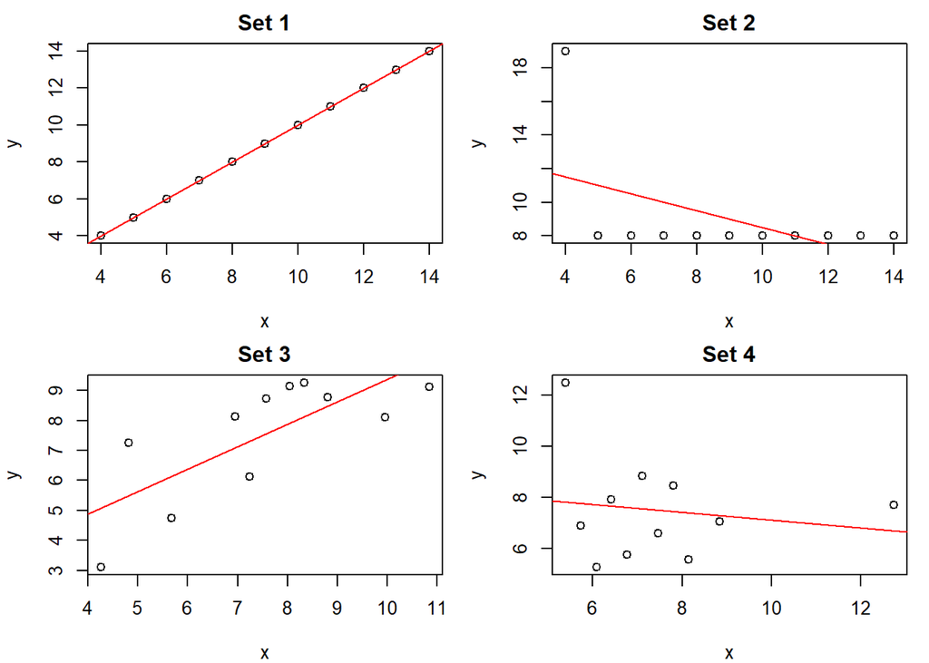

```
## Summary Statistics for Set 4 :
## Mean X: 7.5
## Mean Y: 7.500909
## Variance X: 4.12262
## Variance Y: 4.123249
## Correlation for Set 4 :
## -0.1554718
```

```r
# Adjust figure margins
par(mfrow = c(2, 2), mar = c(4, 4, 2, 1))

# Plotting the datasets and adding abline
for (i in 1:4) {
  x <- anscombe[, (2 * i - 1)]
  y <- anscombe[, 2 * i]

  plot(x, y, main = paste("Set", i))
  abline(lm(y ~ x), col = "red")

  # Calculate summary statistics
  cat("Summary Statistics for Set", i, ":\n")
  cat("Mean X:", mean(x), "\n")
  cat("Mean Y:", mean(y), "\n")
  cat("Variance X:", var(x), "\n")
  cat("Variance Y:", var(y), "\n")

  # Calculate correlation
  cat("Correlation for Set", i, ":\n")
  cat(cor(x, y), "\n\n")
}
```

```r
# Reset plot layout
par(mfrow = c(1, 1))
```

## INSIGHTS TO THE ANSCOMBE ANALYSIS AND PAPER

As stated previously, we will attempt to address some key insights as drawn to our attention by this paper.

### WHY IS TOO LITTLE ATTENTION GIVEN TO DATA VISUALIZATION?

In the paper “Graphs in Statistical Analysis,” Anscombe argues that too little attention is given to data visualization because many researchers rely too heavily on numerical summaries and statistical tests, which can obscure important features of the data. He notes that graphical displays can reveal patterns, outliers, and other aspects of the data that may not be immediately apparent from summary statistics or test results. However, he also acknowledges that creating effective visual displays of data requires skill and experience, which may be lacking in some researchers.

Therefore, Anscombe advocates for increased attention to data visualization and for training researchers in the principles and techniques of graphical analysis. More on recent developments in data visualizations can be seen [here](https://paperswithcode.com/task/data-visualization)

### THE USEFULNESS OF GRAPHS

Graphs have several useful applications, including the following:

**Providing a visual representation of data**: Graphs allow us to see patterns, trends, and relationships in data that may not be apparent from simply looking at numbers.

**Simplifying complex data**: Graphs can make complex data more accessible and easier to understand by presenting it in a clear and concise format.

**Communicating information effectively**: Graphs are an effective means of communicating information to others, whether it be in a research paper, presentation, or report.

**Facilitating decision-making**: Graphs can help decision-makers understand the implications of different options by presenting data in a way that is easy to interpret and compare.

**Enhancing data exploration**: Graphs can be used to explore data in an interactive and dynamic way, allowing analysts to identify trends and patterns that may not be immediately apparent.

**Supporting hypothesis testing**: Graphs can be used to visualize data in a way that supports hypothesis testing by providing evidence for or against a particular hypothesis.

**Improving data quality**: Graphs can be used to identify outliers and other anomalies in data that may indicate errors or inaccuracies.

### WHAT TO DO WHEN DEALING WITH BIVARIATE OR MULTIVRAITE DATA

In the case of Anscombe data, we will say the data is multivariate as we have x1, x2, x3, x4 with their corresponding dependent variable. We will explain the bivariate case point.

The first thing to do when dealing with bivariate data is to visualize the relationship between the two variables using a scatter plot. This will give an idea of the pattern of association, if any, between the variables. Five things that can happen when this is done include:

**a. Identification of patterns**: A scatter plot can help identify patterns in the data, such as a linear or non-linear relationship between the two variables.

**b. Outlier detection**: Outliers can be identified on a scatter plot as points that fall far away from the general pattern of the data.

**c. Identification of correlation**: A scatter plot can help identify the direction and strength of the correlation between the two variables, with positive correlation indicated by points moving up and to the right, and negative correlation indicated by points moving down and to the right.

**d. Identification of clusters**: A scatter plot can help identify clusters or groups of data points that may be of interest.

**e. Identification of data quality issues**: A scatter plot can reveal issues with the data quality, such as missing values or errors in data entry, that may need to be addressed before further analysis.

### ADVANTAGE OF GRAPH VISUALS OVER OLS CALCULATIONS

Graphs can reveal important aspects of the relationship between two variables that may be missed by ordinary calculations for linear regression. Here are some things that can be detected with graphs:

**Non-linearity:** Graphs can reveal if the relationship between the two variables is not linear, which can affect the validity of linear regression analysis.

**Outliers:** Graphs can identify outliers that can significantly impact the regression line and its ability to accurately predict future values.

**Heteroscedasticity:** Graphs can reveal if the variance of the residuals (the difference between the predicted values and the actual values) is not constant across the range of the independent variable, which can violate one of the assumptions of linear regression.

**Influential observations:** Graphs can identify observations that exert an undue influence on the regression line, such as extreme values or influential points, that can affect the validity of the model.

**Collinearity:** Graphs can reveal if there is a high degree of correlation between the independent variables, which can impact the interpretation of the regression coefficients.

### THINGS TO LOOK OUT FOR IN A RESIDUAL PLOT AGAINST FITTED VALUES

In the cause of examining the work of Anscombe there are discoveries that have been made as regards residual plots. When examining a plot of residuals against fitted values or the independent variable in linear regression analysis, there are a few things to look for such as the following:

**Pattern:** Check for any visible patterns in the plot, such as a curved shape or a U-shape. This can indicate that the model is not capturing the relationship between the variables accurately, and that non-linear terms may need to be included in the model.

**Spread:** Look for any areas of the plot where the residuals are more spread out or more concentrated. Ideally, the residuals should be evenly distributed around the zero line (horizontal axis) with no visible pattern.

**Outliers:** Check for any outliers in the plot, which are data points that fall far away from the main cluster of residuals. Outliers can have a significant impact on the model and may need to be removed or investigated further.

**Homoscedasticity:** Examine whether the spread of the residuals is consistent across all values of the independent variable. If there is a visible pattern in the spread, such as the residuals becoming more spread out at higher values of the independent variable, this can indicate heteroscedasticity and suggest the need for a different modeling approach.

**Independence:** Check for any visible patterns in the residuals over time or across observations. If there is a visible pattern, such as the residuals becoming more positive or negative over time, this can indicate that the assumption of independence has been violated, and the model may need to be revised or adjusted.

## COMPUTATION OF BASIC SUMMARY STATISTICS AND PLOTS USING R

### MEAN

In data visualization, the term “mean” refers to a statistical measure that represents the average value of a set of data points. It is commonly denoted as the arithmetic mean and is calculated by summing up all the values in the dataset and dividing the sum by the total number of values.

The mean is a measure of central tendency and is used to provide a representative value that summarizes the data distribution. It is widely used in data analysis and visualization to understand the typical or average value of a data set.

When visualizing data, the mean can be depicted in various ways depending on the type of visualization. Some common representations include:

**Bar Chart** The mean value can be shown as a horizontal or vertical line within a bar chart, indicating the average value of a particular category or group.

**Line Chart** The mean value can be displayed as a line connecting points on a line chart, representing the average trend or pattern in a time series.

**Box Plot** The mean value can be represented as a dot or symbol within a box plot, providing insight into the central tendency of the data distribution along with other statistical measures like the median and quartiles.

**Histogram** The mean value can be shown as a vertical line within a histogram, indicating the average position of the data distribution along the x-axis.

Visualizing the mean can help in understanding the overall trend or central value of a dataset, providing valuable insights into the characteristics and behavior of the data. It serves as a useful summary statistic when exploring and communicating data through visual representations. (More about [mean](https://www.researchgate.net/topic/Mean-Median-Mode/publications))

The Anscombe’s quartet data set consists of four sets of x-y coordinate values. To calculate the mean of the data, we create an R function that takes the dataset as an input and calculates the mean for each set separately.

In this example, the `calculate_mean()` function takes the `dataset` as an input. It uses the `lapply()` function to apply the `mean()` function to each set in the data set. The result is a list of means for each set. Finally, the means are printed using the `print()` function.

To run this code, you will need to ensure that the `anscombe` data set is available in your R environment. The data set is provided by default in R, so you can load it using the `data(anscombe)` command before using the `calculate_mean()` function.

```r
# Function to calculate mean of Anscombe dataset
calculate_mean <- function(dataset) {
  means <- lapply(dataset, function(set) {
    mean(set)
  })
  return(means)
}
```

```r
# Load the Anscombe dataset
data(anscombe)

# Calculate the means
means <- calculate_mean(anscombe)

# Print the means
print(means)
```

```
## $x1
## [1] 9
##
## $x2
## [1] 9
##
## $x3
## [1] 9
##
## $x4
## [1] 9
##
## $y1
## [1] 7.500909
##
## $y2
## [1] 7.500909
##
## $y3
## [1] 7.5
##
## $y4
## [1] 7.500909
```

As can be observed, though the data set are from very different samples, the mean of each set are similar to each other. So, if inference is to be drawn based on this, we will be making a wrong inference. This goes along way to portray the aurgment as presented by Anscombe.

### REGRESSION COEFFICIENT

In data visualization, regression coefficients refer to the parameters estimated in a regression analysis. Regression analysis is a statistical technique used to model the relationship between a dependent variable and one or more independent variables.

The regression coefficients represent the effect or impact of the independent variables on the dependent variable. They quantify the slope or change in the dependent variable for each unit change in the independent variable(s).

In data visualization, regression coefficients can be visualized to communicate the strength and direction of the relationship between variables. Some common visualization techniques for regression coefficients include:

**Scatter Plot with Regression Line:**

A scatter plot can be used to plot the data points and then a regression line can be added to represent the estimated relationship. The slope of the regression line corresponds to the regression coefficient.

**Bar Chart**

If the independent variable is categorical, a bar chart can be used to display the regression coefficients for each category. The height of the bars represents the magnitude of the coefficients, and the direction of the bars indicates the positive or negative relationship with the dependent variable.

**Heatmap**

A heatmap can be used to visualize the regression coefficients as a matrix, where the rows represent the dependent variables and the columns represent the independent variables. The color intensity or shading can represent the magnitude of the coefficients, making it easy to identify strong or weak relationships.

By visualizing regression coefficients, one can gain insights into the impact of independent variables on the dependent variable. This can help in understanding the strength and direction of the relationships, identifying influential factors, and making predictions or inferences based on the regression model.

To calculate the regression coefficient (slope) of the Anscombe data, we create an R function that takes the data set as an input and performs linear regression analysis on each set.

```r
# Function to calculate regression coefficient of Anscombe dataset
calculate_regression_coefficient_anscombe <- function(dataset) {
  regression_coefficients <- numeric(length(dataset))

  for (i in seq_along(dataset)) {
    current_data <- dataset[[i]]

    # Fit a simple linear regression model
    model <- lm(y ~ x, data = current_data)

    # Extract the regression coefficient
    coefficient <- coef(model)[2]  # 2 corresponds to the coefficient of x

    regression_coefficients[i] <- coefficient
  }

  return(regression_coefficients)
}
```

```r
# Load the Anscombe dataset
data(anscombe)

# Restructure the dataset
mydata <- data.frame(x = c(anscombe[, 1], anscombe[, 3], anscombe[, 5], anscombe[, 7]),
                     y = c(anscombe[, 2], anscombe[, 4], anscombe[, 6], anscombe[, 8]),
                     set = rep(1:4, each = nrow(anscombe)))
```

```r
# Calculate the regression coefficients for all sets
regression_coefficients <- calculate_regression_coefficient_anscombe(split(mydata, mydata$set))

print(regression_coefficients)
```

```
## [1]  1.0000000 -0.5000000  0.7500381 -0.1554836
```

The above result gives the regression coefficient of the equation. More on [regression coefficient](https://methods.sagepub.com/reference/encyc-of-research-design/n374.xml)

### REGRESSION SUM OF SQUARES

In data visualization, the regression sum of squares (SSR) is a statistical measure used to assess the variability explained by a regression model. It quantifies the variation in the dependent variable that is accounted for by the regression equation.

In the context of data visualization, the SSR can be useful in understanding the goodness of fit of a regression model and assessing how well the model captures the observed data.

One common application of SSR in data visualization is in the context of regression line plots. A regression line is often fitted to a scatter plot of data points to represent the relationship between the independent and dependent variables. The SSR is used to determine how well the regression line fits the observed data. A smaller SSR indicates a better fit, suggesting that the regression model explains a larger portion of the variation in the dependent variable.

By visualizing the regression line and considering the SSR, one can assess the strength and appropriateness of the linear relationship between variables. This can help in understanding the predictive power of the regression model and evaluating its effectiveness in explaining the observed data.

We will write a function to compute the regression sum of squares. This function takes two arguments: `dataset`, which represents the Anscombe data set (in the same format as before), and `coefficients`, which is a vector of regression coefficients for each set. It iterates through each set, calculates the predicted values using the regression coefficient and the x-values, and then computes the sum of squared differences between the predicted values and the corresponding y-values.

```r
# TO FIND THE REGRESSION SUM OF SQUARES
calculate_regression_sum_of_squares_anscombe <- function(dataset, coefficients) {
  regression_sumsquares <- numeric(length(dataset))

  for (i in seq_along(dataset)) {
    current_data <- dataset[[i]]
    current_coefficient <- coefficients[i]

    # Calculate predicted values
    predicted <- current_coefficient * current_data$x

    # Calculate sum of squared differences
    ssr <- sum((predicted - current_data$y)^2)

    regression_sumsquares[i] <- ssr
  }

  return(regression_sumsquares)
}
```

To compute the statistic, we will call the function with reference to our data set.

```r
# Calculate the regression sum of squares for all sets
regression_sumsquares <- calculate_regression_sum_of_squares_anscombe(split(mydata, mydata$set), regression_coefficients)

print(regression_sumsquares)
```

```
## [1] 5.837571e-29 2.087250e+03 5.672750e+01 8.665286e+02
```

More on [RSS](https://www.sciencedirect.com/topics/mathematics/sum-of-squares)

### THE RESIDUAL SUM OF SQUARES

In data visualization, the residual sum of squares (RSS) is a statistical measure used to evaluate the goodness of fit of a regression model. It quantifies the total variation that is not explained by the regression model, represented by the difference between the observed values of the dependent variable and the predicted values from the regression equation.

The RSS is calculated by summing the squared differences between the observed values of the dependent variable and the corresponding predicted values from the regression model. It represents the unexplained variation or the residuals, which are the discrepancies between the observed data and the regression line or curve.

In the context of data visualization, the RSS can be useful in assessing the accuracy and adequacy of the regression model in capturing the observed data. By minimizing the RSS, the regression model aims to minimize the residuals and provide the best fit to the data.

When visualizing the RSS, it is common to use a scatter plot with a regression line or curve. The residuals, which are the vertical distances between the observed data points and the regression line or curve, are typically shown as vertical lines or dots. A larger RSS indicates a poorer fit of the regression model to the data, as it implies more unexplained variation and larger residuals.

By examining the RSS and visualizing the residuals, one can assess the goodness of fit of the regression model, identify potential outliers or patterns in the residuals, and evaluate the effectiveness of the model in explaining the observed data.

To calculate the residual sum of squares (RSS) based on the regression coefficients of the Anscombe data set, we will compute the residuals for each set and then calculate the sum of the squared residuals. The following function will do just that for us.

```r
calculate_residual_sum_of_squares_anscombe <- function(dataset, coefficients) {
  residual_sumsquares <- numeric(length(dataset))

  for (i in seq_along(dataset)) {
    current_data <- dataset[[i]]
    current_coefficient <- coefficients[i]

    # Calculate predicted values
    predicted <- current_coefficient * current_data$x

    # Calculate residuals
    residuals <- current_data$y - predicted

    # Calculate sum of squared residuals
    rss <- sum(residuals^2)

    residual_sumsquares[i] <- rss
  }

  return(residual_sumsquares)
}
```

This function calculates the residuals by subtracting the predicted values from the actual y-values. Then, it computes the sum of squared residuals. To use this function with the Anscombe dataset, you can follow these steps:

```r
# Load the Anscombe dataset
data(anscombe)

# Restructure the dataset
mydata <- data.frame(x = c(anscombe[, 1], anscombe[, 3], anscombe[, 5], anscombe[, 7]),
                     y = c(anscombe[, 2], anscombe[, 4], anscombe[, 6], anscombe[, 8]),
                     set = rep(1:4, each = nrow(anscombe)))

# Calculate the regression coefficients for all sets
regression_coefficients <- calculate_regression_coefficient_anscombe(split(mydata, mydata$set))

# Calculate the residual sum of squares for all sets
residual_sumsquares <- calculate_residual_sum_of_squares_anscombe(split(mydata, mydata$set), regression_coefficients)

print(residual_sumsquares)
```

```
## [1] 5.837571e-29 2.087250e+03 5.672750e+01 8.665286e+02
```

This will calculate and print the residual sum of squares for each set of x and y values in the Anscombe data set based on the regression coefficients. More on [RSS](https://www.sciencedirect.com/topics/mathematics/residual-sum)

### ESTIMATED STANDARD ERROR (RC)

The estimated standard error is calculated based on the variability of the residuals (differences between observed values and predicted values) and the sample size. It provides an indication of the uncertainty surrounding the estimated coefficient and is often used to construct confidence intervals and perform hypothesis testing in regression analysis.

In the context of data visualization, the estimated standard error is typically used in conjunction with the regression coefficient to visualize the uncertainty or variability associated with the estimated relationship between variables.

One common way to visualize the estimated standard error is by using error bars. Error bars can be added to a scatter plot or line plot to indicate the range within which the true value of the coefficient is likely to fall. The length of the error bar represents the estimated standard error, and it provides a visual representation of the precision of the estimated coefficient.

By visualizing the estimated standard error, one can better understand the uncertainty associated with the regression coefficient estimate and assess the reliability of the relationship between variables. It helps in interpreting the results of a regression model and provides insights into the level of confidence one can have in the estimated coefficient.

```r
calculate_estimated_standard_error_anscombe <- function(dataset, coefficients) {
  residual_sumsquares <- calculate_residual_sum_of_squares_anscombe(dataset, coefficients)

  df <- length(dataset[[1]]) - 2  # degrees of freedom: n - 2 for simple linear regression

  # Calculate the estimated standard error
  se <- sqrt(residual_sumsquares / df)

  return(se)
}
```

To use this function with the Anscombe dataset, you can do the following:

```r
# Calculate the estimated standard error for all sets
estimated_standard_error <- calculate_estimated_standard_error_anscombe(split(mydata, mydata$set), regression_coefficients)

print(estimated_standard_error)
```

```
## [1] 7.640400e-15 4.568643e+01 7.531766e+00 2.943686e+01
```

This will calculate and print the estimated standard error for each set of x and y values in the Anscombe data set based on the regression coefficients.

### MULTIPLE R-SQUARED

In data visualization, Multiple R-squared (R-squared) is a statistical measure used to assess the goodness of fit of a regression model. It quantifies the proportion of the total variation in the dependent variable that is explained by the independent variables in the regression model.

R-squared is a value between 0 and 1, where: - A value of 0 indicates that the independent variables in the regression model do not explain any of the variation in the dependent variable. - A value of 1 indicates that the independent variables in the regression model explain all of the variation in the dependent variable.

R-squared is calculated by comparing the variation in the dependent variable that is explained by the regression model (sum of squares explained, SSE) to the total variation in the dependent variable (total sum of squares, SST).

In the context of data visualization, R-squared is often used to communicate the strength of the relationship between variables and the adequacy of the regression model in capturing the observed data.

When visualizing R-squared, it is common to use scatter plots with a regression line or curve. The R-squared value can be displayed as a label or annotation on the plot to provide a quantitative measure of how well the regression model fits the data. A higher R-squared value indicates a better fit, suggesting that the independent variables explain a larger portion of the variation in the dependent variable.

However, it is important to note that R-squared should be interpreted in conjunction with other model evaluation metrics and should not be the sole criterion for assessing the quality of a regression model.

By visualizing R-squared, one can gain insights into the explanatory power of the regression model and understand the proportion of the variation in the dependent variable that can be attributed to the independent variables.

Here’s an R function that calculates the multiple R-squared. To calculate the multiple R-squared (R²) based on the regression coefficients of the Anscombe dataset, you need to compute the total sum of squares (TSS) and the residual sum of squares (RSS).

```r
###### TO CALCULATE THE MULTIPLE R-SQUARED
####
calculate_multiple_r_squared_anscombe <- function(dataset, coefficients) {
  multiple_r_squared <- numeric(length(dataset))

  for (i in seq_along(dataset)) {
    current_data <- dataset[[i]]
    current_coefficient <- coefficients[i]

    # Add an intercept term to the model formula
    model_formula <- as.formula(y ~ x)

    # Fit the multiple regression model
    model <- lm(model_formula, data = current_data)

    # Calculate the multiple R-squared
    r_squared <- summary(model)$r.squared

    multiple_r_squared[i] <- r_squared
  }

  return(multiple_r_squared)
}
```

To use this function with the Anscombe dataset, you can do the following:

```r
# Calculate the multiple R-squared for all sets
multiple_r_squared <- calculate_multiple_r_squared_anscombe(split(mydata, mydata$set), regression_coefficients)

print(multiple_r_squared)
```

```
## [1] 1.00000000 0.25000000 0.56250810 0.02417148
```

More on [Multiple R-squared](https://statisticsbyjim.com/regression/interpret-r-squared-regression/)

# CONCLUSION

The Anscombe’s quartet is a collection of four data sets that have identical or very similar summary statistics but exhibit distinct and diverse patterns when visualized. The quartet was introduced by the statistician Francis Anscombe in 1973 to emphasize the importance of data visualization in understanding and interpreting data.

The quartet serves as a reminder that data visualization is an essential tool in exploratory data analysis. It demonstrates that summary statistics alone can be deceptive and can mask important nuances and variations in the data. By visually examining the datasets in the quartet, one can gain a deeper understanding of the data’s characteristics and make more informed decisions about modeling and analysis.

The Anscombe’s quartet has become a well-known example in statistical education and data analysis to illustrate the concept of “same statistics, different data.” It emphasizes the need to complement statistical analysis with visual exploration to gain insights and avoid potential pitfalls of relying solely on summary statistics.

The Anscombe analysis has had a significant impact on today’s research approach to data by highlighting the importance of data visualization in data analysis and interpretation. It serves as a reminder that summary statistics alone are insufficient to fully understand the complexities and patterns within a data set.

Researchers now recognize that visualizing data is crucial for uncovering hidden insights, identifying outliers or anomalies, detecting non-linear relationships, and validating assumptions. Data visualization allows researchers to explore the data from multiple angles, visually inspect distributions, observe trends, and assess the goodness of fit of statistical models.

The Anscombe analysis has prompted a shift towards a more exploratory and visual approach to data analysis. Researchers are encouraged to plot their data, create visualizations, and examine the patterns and relationships within the dataset before diving into complex statistical analyses. Visualizations help researchers to formulate hypotheses, make informed decisions about modeling techniques, identify data quality issues, and communicate findings effectively.

Additionally, the impact of the Anscombe analysis extends beyond traditional research approaches. It has influenced the development of interactive and dynamic visualization tools, allowing researchers to interact with the data in real-time, manipulate variables, and explore different scenarios. These tools enhance the understanding and interpretation of data, enable data-driven decision-making, and facilitate collaboration among researchers.

Overall, the Anscombe analysis has played a pivotal role in emphasizing the indispensable role of data visualization in modern research. It has spurred a greater appreciation for visual exploration and has led to more robust, informed, and transparent data analysis practices across various disciplines.

# REFERENCE

Anscombe, Francis J. (1973). Graphs in Statistical Analysis. The American Statistician, 27, 17 - 21. doi: 10.2307/2682899

Cherniavskyi, Vasyl & Nosov, Pavlo & Koretsky, Oleksiy & D.M., Onyshko & Prokopchuk, Yurii. (2023). APPROACHES TO AUTOMATION OF PROCESSES OF IDENTIFICATION OF SEAFARER’S PHYSIOLOGICAL PARAMETERS.

vom Hofe, R. (Ed.) (2010). . (Vols. 1-0). SAGE Publications, Inc., https://doi.org/10.4135/9781412961288

Xin-She Yang,4 - Data fitting and regression, Editor(s): Xin-She Yang, Introduction to Algorithms for Data Mining and Machine Learning, Academic Press, 2019, Pages 67-90, ISBN 9780128172162, https://doi.org/10.1016/B978-0-12-817216-2.00011-9. (https://www.sciencedirect.com/science/article/pii/B9780128172162000119)